# ORLA6541_Final_YueSummerWu

YueSummerWu

2024-12-10

# 1. Loading Necessary Packages

```r
library(readxl) # Reading excel files
library(httr) # Working with URLs and HTTP requests
library(zip) # Working with compressed ZIP files in R
library(tidyverse) # Data preparation
library(dplyr) # Data preparation
library(janitor) # Cleaning variable names
library(DMwR) # For SMOTE
# DMwR has been removed from CRAN, but can be downloaded using this code:
## remotes::install_github("cran/DMwR")
library(rpart) # For creating Classification and Regression Trees (CART)
library(caret) # For training and evaluating machine learning models
```

```r
library(rpart.plot) # For plotting decision trees
library(randomForest) # For random forest
library(pROC) # For calculating and plotting ROC AUC
library(ggplot2) # Visualization
library(ggpubr) # Visualization
library(cowplot) # Visualization
library(scales) # Visualization
library(ggtext) # Visualization
library(GGally) # Visualization
library(knitr) # Data frame to markdown table
library(grateful) # Citing R packages used
```

# 2. Dataset Construction

## 2.1 Importing Data

### 2.1.1 School Report Card Data

```r
# Define a temporary file for the zip
temp_src <- tempfile(fileext = ".zip")
src_zip_link <- "https://www.dpi.nc.gov/documents/src-datasets-2023/open"

# Download the zip file
GET(src_zip_link, write_disk(temp_src, overwrite = TRUE))
```

```
## Response [https://www.dpi.nc.gov/documents/src-datasets-2023/open]
##   Date: 2024-12-17 04:32
##   Status: 200
##   Content-Type: application/zip
##   Size: 212 MB
## <ON DISK>  /var/folders/9b/7s3y6tb91md6y_vlqq56g41c0000gn/T//Rtmpcy1pqn/file3bef6051af76.zip
```

```r
# Define an output directory to unzip files
output_dir_src <- tempdir()

# Unzip the file into the output directory
unzip(temp_src, exdir = output_dir_src)

# List all files in the unzipped directory
src_files <- list.files(output_dir_src, recursive = TRUE, full.names = TRUE)

# Load all .xlsx files into a list
src_data_list <- suppressWarnings(lapply(src_files[grepl("\\.xlsx$", src_files)], read_excel))

# Assign names to each dataset based on file names for easy access
names(src_data_list) <- basename(src_files[grepl("\\.xlsx$", src_files)])
```

### 2.1.2 Non-SCR Data

#### Crime

```r
# Crime counts by school from AY 2021-2022
download.file("https://www.dpi.nc.gov/tablec12-school-level-crime-counts-and-rates-2021-22/open", "crime_2022.xlsx")

# Crime counts by school from AY 2022-2023
download.file("https://www.dpi.nc.gov/documents/consolidated-reports/tablec10-school-level-crime-counts-and-rates-2023/open", "crime_2023.xlsx")
```

#### Student Reassignment

```r
# Student assignment data from ay 2021-2022
download.file("https://www.dpi.nc.gov/tabler7-student-reassignments-psu-and-school-2021-22/open", "reassign_2022.xlsx")

# Student assignment data from ay 2022-2023
download.file("https://www.dpi.nc.gov/documents/consolidated-reports/tabler7-student-reassignments-psu-and-school-2023/open", "reassign_2023.xlsx")
```

#### Suspension

```r
# Short term suspension data from AY 2021-2022
download.file("https://www.dpi.nc.gov/tables9-short-term-suspension-stats-schools-2021-22/open", "sts_2022.xlsx")

# Short term suspension data from AY 2022-2023
download.file("https://www.dpi.nc.gov/documents/consolidated-reports/tables9-short-term-suspension-stats-schools-2023/open", "sts_2023.xlsx")
```

## 2.2 Data Extraction and Engineering

### 2.2.1 Creating Outcome Variable: `performance`

The outcome variable of this analysis is whether a school is identified as low-performing based on NC school performance grade system.

```r
# List of low-performing schools in AY 2021-2022
lp_2022 <- src_data_list[["rcd_acc_lowperf.xlsx"]] |>
  # Non-charter public schools in AY 2021-2022
  filter(year == 2022,
         # Charter schools and district code contain letters
         !grepl("[a-zA-Z]", agency_code)) |>
  # Transforming the outcome varaible from Y/N to Low/High
  mutate(performance = ifelse(lp_school == "Y", "Low", "High")) |>
  # Keeping needed varaibles
  select(agency_code, performance)

# List of low-performing schools in AY 2022-2023
lp_2023 <- src_data_list[["rcd_acc_lowperf.xlsx"]] |>
  # Non-charter public schools in AY 2022-2023
  filter(year == 2023,
         # Charter schools and district code contain letters
         !grepl("[a-zA-Z]", agency_code)) |>
  # Transforming the outcome varaible from Y/N to Low/High
  mutate(performance = ifelse(lp_school == "Y", "Low", "High")) |>
  # Keeping needed variables
  select(agency_code, performance)
```

### 2.2.2 Creating Predictors

The variable selection is based on the consideration of three aspects: 1) Opportunity equity indicators proposed by NASEM; 2) Literature review; 2) Data Availability.

- Teaching effectiveness

```r
# Teacher experiences in AY 2021-2022
qualification_2022 <- src_data_list[["rcd_eq.xlsx"]] |>
  # Data from AY 2021-2022
  filter(year == 2022) |>
  # Keeping needed varaibles
  select(agency_code, pct_beg_teachers, pct_prov_teachers)

# Teacher experiences in AY 2022-2023
qualification_2023 <- src_data_list[["rcd_eq.xlsx"]] |>
  # Data from AY 2022-2023
  filter(year == 2023) |>
   # Keeping needed varaibles
  select(agency_code, pct_beg_teachers, pct_prov_teachers)
```

```r
# Percentage of effective teachers in AY 2021-2022
effectiveness_2022 <- src_data_list[["rcd_effectiveness3.xlsx"]] |>
  # Data from AY 2021-2022
  filter(year == 2022) |>
  # Calculating percentage of effective or very effective teachers
  mutate(pct_eff_teachers = (eff_pct + he_pct) * 100, na.rm = TRUE) |>
  # Keeping needed varaibles
  select(agency_code, pct_eff_teachers)

# Percentage of effective teachers in AY 2022-2023
effectiveness_2023 <- src_data_list[["rcd_effectiveness3.xlsx"]] |>
  # Data from AY 2022-2023
  filter(year == 2023) |>
  # Calculating percentage of effective or very effective teachers
  mutate(pct_eff_teachers = (eff_pct + he_pct) * 100, na.rm = TRUE) |>
  # Keeping needed varaibles
  select(agency_code, pct_eff_teachers)
```

- Finance

```r
# Funding and per-pupil expenditure for AY 2021-2022
finance_2022 <- src_data_list[["rcd_funds2.xlsx"]] |>
  # Data from AY 2021-2022
  filter(year == 2022,
         # Only considering total expenditure without category breakdown
         expenditure_category == "TOTAL") |>
  # Keeping needed varaibles
  select(agency_code, total_funds, total_ppe)

# Funding and per-pupil expenditure for AY 2022-2023
finance_2023 <- src_data_list[["rcd_funds2.xlsx"]] |>
  # Data from AY 2022-2023
  filter(year == 2023,
         # Only considering total expenditure without category breakdown
         expenditure_category == "TOTAL") |>
  # Keeping needed varaibles
  select(agency_code, total_funds, total_ppe)
```

- Chronic Absenteeism

```r
# Chronic absenteeism rate for AY 2021-2022
chronic_absent_2022 <- src_data_list[["rcd_chronic_absent.xlsx"]] |>
  # Data from AY 2021-2022
  filter(year == 2022,
         # All students
         subgroup == "ALL") |>
  # Calculating percentage of chronic absenteeism
  mutate(pct_chro_absent = pct * 100) |>
    # Keeping needed variables
  select(agency_code, pct_chro_absent)

# Chronic absenteeism rate for AY 2022-2023
chronic_absent_2023 <- src_data_list[["rcd_chronic_absent.xlsx"]] |>
  # Data from AY 2021-2022
  filter(year == 2023,
         # All students
         subgroup == "ALL") |>
  # Calculating percentage of chronic absenteeism
  mutate(pct_chro_absent = pct * 100) |>
  # Keeping needed variables
  select(agency_code, pct_chro_absent)
```

- School climate / Learning environment

```r
# Getting number of crime acts per 1000 students in AY 2021-2022
crime_2022 <- readxl::read_xlsx("crime_2022.xlsx", skip = 2) |>
  # Styling column names
  clean_names() |>
  # Keeping needed variables
  select(agency_code = school_code,
         acts_per_1k = total_number_of_acts_per_1_000_students)
# Getting number of crime acts per 1000 students in AY 2022-2023
crime_2023 <- readxl::read_xlsx("crime_2023.xlsx", skip = 2) |>
  # Styling column names
  clean_names() |>
  # Keeping needed variables
  select(agency_code = school_code,
         acts_per_1k = total_number_of_acts_per_1_000_students)
```

```r
# Average class size for AY 2021-2022
class_size_2022 <- src_data_list[["rcd_sar.xlsx"]] |>
  # Keeping 2022 data
  filter(year == 2022) |>
  # Getting average class size
  group_by(agency_code) |>
  summarise(class_size = mean(avg_size, na.rm = TRUE)) |>
  ungroup()

# Average class size for AY 2022-2023
class_size_2023 <- src_data_list[["rcd_sar.xlsx"]] |>
  # Keeping 2023 data
  filter(year == 2023) |>
  # Getting average class size
  group_by(agency_code) |>
  summarise(class_size = mean(avg_size, na.rm = TRUE)) |>
  ungroup()
```

```r
# Access to digital divice and books in AY 2021-2022
digital_media_inventory_2022 <- src_data_list[["rcd_dlmi.xlsx"]] |>
  # Keeping 2022 data
  filter(year == 2022) |>
  # Recoding the dummy variables
  mutate(flag_device_access = ifelse(device_access == "Yes", 1, 0),
         flag_device_home = ifelse(device_home == "Yes", 1, 0))|>
  # Keeping variables needed
  select(agency_code,
         flag_device_access,
         flag_device_home,
         books_per_student = books)

# Access to digital divice and books in AY 2022-2023
digital_media_inventory_2023 <- src_data_list[["rcd_dlmi.xlsx"]] |>
  # Keeping 2023 data
  filter(year == 2023) |>
  # Recoding the dummy variables
  mutate(flag_device_access = ifelse(device_access == "Yes", 1, 0),
         flag_device_home = ifelse(device_home == "Yes", 1, 0))|>
  # Keeping variables needed
  select(agency_code,
         flag_device_access,
         flag_device_home,
         books_per_student = books)
```

- Discipline

```r
# Number of short-term suspension and length of short term suspension in AY 2021-2022
sts_2022 <- readxl::read_xlsx("sts_2022.xlsx", skip = 1) |>
  # Cleaning column names
  clean_names() |>
  # Compisite agency code
  mutate(agency_code = paste0(psu_number, school_code)) |>
  # Keeping variables needed
  select(agency_code,
         days_per_sts = days_per_sts,
         sts_per_1k = sts_per_1_000_students)

sts_2023 <- readxl::read_xlsx("sts_2023.xlsx", skip = 1)  %>%
  # Clean column names
  clean_names() %>%
  # Create composite agency code
  mutate(agency_code = paste0(psu_number, school_code)) %>%
  # Select necessary variables
  select(agency_code,
         days_per_sts = avg_days_per_sts,
         sts_per_1k = sts_per_1_000_students)
```

```r
# Number of in-school suspension, average days per suspension, number of students placed to alternative programs because of discipline reasons 2021-2022
reassign_2022 <- readxl::read_xlsx("reassign_2022.xlsx", skip = 1) |>
  # Cleaning column names
  clean_names() |>
  # Composite agency code
  mutate(agency_code = paste0(psu_number, school_code)) |>
  # Keeping variables needed
  select(agency_code,
         iss_per_1k = iss_per_1_000_students,
         days_per_iss = days_per_iss,
         placement_per_1k = alps_placements_per_1_000_students)

# Number of in-school suspension, average days per suspension, number of students placed to alternative programs because of discipline reasons 2022-2023
reassign_2023 <- readxl::read_xlsx("reassign_2023.xlsx", skip = 1) |>
  # Cleaning column names
  clean_names() |>
  # Composite agency code
  mutate(agency_code = paste0(psu_number, school_code)) |>
  select(agency_code,
         iss_per_1k = iss_per_1_000_students,
         days_per_iss = avg_days_per_iss,
         placement_per_1k = alps_placements_per_1_000_students)
```

### 2.2.3 Merging All Data

- AY 2021-2022

```r
# List of data frames to merge
data_list_2022 <- list(lp_2022, qualification_2022, effectiveness_2022, finance_2022, chronic_absent_2022, crime_2022, class_size_2022, digital_media_inventory_2022, sts_2022, reassign_2022)

# Merging all data frames by "agency_code"
merged_data_2022 <- reduce(data_list_2022, ~ left_join(.x, .y, by = "agency_code"))

# Clean 2022 data
data_2022 <- merged_data_2022 |>
  # Making school code the row index
  column_to_rownames(var = "agency_code") |>
  # Turning variables to numeric
  mutate(days_per_sts = as.numeric(days_per_sts),
         books_per_student = as.numeric(books_per_student)) |>
  # Turning outcome variable to categorical
  mutate(performance = as.factor(performance))
# The warning was induced by the suppresed value, so they are missing valeus anyway.
```

- AY 2022-2023

```r
# List of data frames to merge
data_list_2023 <- list(lp_2023, qualification_2023, effectiveness_2023, finance_2023, chronic_absent_2023, crime_2023, class_size_2023, digital_media_inventory_2023, sts_2023, reassign_2023)

# Merging all data frames by "agency_code"
merged_data_2023 <- reduce(data_list_2023, ~ left_join(.x, .y, by = "agency_code"))
```

When replicating the codes for 2023, I encountered the error saying the agency_code is not unique. Let’s investigate those observations.

```r
# Getting the duplicated rows
duplicates_2023 <- merged_data_2023 |>
  filter(agency_code %in% agency_code[duplicated(agency_code)])

duplicates_2023
```

```
## # A tibble: 6 × 18
##   agency_code performance pct_beg_teachers pct_prov_teachers pct_eff_teachers
##   <chr>       <chr>                  <dbl>             <dbl>            <dbl>
## 1 298202      High                      NA                NA               NA
## 2 298202      High                      NA                NA               NA
## 3 298203      High                      NA                NA               NA
## 4 298203      High                      NA                NA               NA
## 5 298204      High                      NA                NA               NA
## 6 298204      High                      NA                NA               NA
## # ℹ 13 more variables: total_funds <dbl>, total_ppe <dbl>,
## #   pct_chro_absent <dbl>, acts_per_1k <dbl>, class_size <dbl>,
## #   flag_device_access <dbl>, flag_device_home <dbl>, books_per_student <chr>,
## #   days_per_sts <dbl>, sts_per_1k <dbl>, iss_per_1k <dbl>, days_per_iss <dbl>,
## #   placement_per_1k <dbl>
```

We can see that the for school `298202` and `298203`, the two rows only differ for one variable that comes from the dataset `"sts_2023.xlsx`. School `298204` is literally duplicates in terms of the variables of interests. Let’s see if they the duplicates come from my operations or the original dataset.

```r
duplicate_check <- readxl::read_xlsx("sts_2023.xlsx", skip = 1) |>
  # Cleaning column names
  clean_names() |>
  # Compisite agency code
  mutate(agency_code = paste0(psu_number, school_code)) |>
  # Finding duplicates
  filter(agency_code %in% agency_code[duplicated(agency_code)])

duplicate_check
```

```
## # A tibble: 14 × 11
##    psu_number school_code psu_name           school_name final_adm number_of_sts
##    <chr>      <chr>       <chr>              <chr>           <dbl>         <dbl>
##  1 100        000         Brunswick County … PSU Totals      12799          1887
##  2 100        000         Brunswick County … PSU Totals      12799             1
##  3 298        000         Deaf and Blind Sc… PSU Totals         NA             5
##  4 298        000         Deaf and Blind Sc… PSU Totals        147             5
##  5 298        202         Deaf and Blind Sc… Eastern NC…        NA             3
##  6 298        202         Deaf and Blind Sc… Eastern NC…        42             3
##  7 298        203         Deaf and Blind Sc… Gov. Moreh…        NA             2
##  8 298        203         Deaf and Blind Sc… Gov. Moreh…        45             2
##  9 298        204         Deaf and Blind Sc… NC School …        NA             0
## 10 298        204         Deaf and Blind Sc… NC School …        60             0
## 11 530        000         Lee County Schools PSU Totals       8966          1673
## 12 530        000         Lee County Schools PSU Totals       8966             3
## 13 920        000         Wake County Schoo… PSU Totals     157847         13193
## 14 920        000         Wake County Schoo… PSU Totals     157847             1
## # ℹ 5 more variables: total_sts_days <dbl>, avg_days_per_sts <dbl>,
## #   sts_per_100_students <dbl>, sts_per_1_000_students <dbl>, agency_code <chr>
```

Aha! Catch you! The duplicates came from the original dataset, so it is a data quality issue. For the analysis, I will use the more “complete” row.

```r
# Clean 2023 data
data_2023 <- merged_data_2023 |>
  # Turning variables to numeric
  mutate(days_per_sts = as.numeric(days_per_sts),
         books_per_student = as.numeric(books_per_student)) |>
  # Pick one row of observations for these two schools
  filter(!(agency_code %in% c("298202", "298203") & sts_per_1k == 0)) |>
  # This will filter out the extra row for 298204
  distinct() |>
  # Making school code the row index (this was where I realized the problem)
  column_to_rownames(var = "agency_code") |>
  # Turning outcome variable to categorical
  mutate(performance = as.factor(performance))
# The warning was induced by the suppressed value, so they are missing values anyway.
```

### 2.2.4 Remove `NA`s

```r
# For 2022 data
data_2022_cleaned <- na.omit(data_2022)

# For 2023 data
data_2023_cleaned <- na.omit(data_2023)
```

# 3. Exploratory Data Analysis

## 3.1 Descriptive Statistics (Using Datasets with `NA`s)

```r
# Getting a dataframe for descriptive statistics
summary_df1 <- data.frame(
  N = sapply(data_2022, function(x) sum(!is.na(x))),
  Min = sapply(data_2022, function(x) if(is.numeric(x)) round(min(x, na.rm = TRUE), 2) else NA),
  Max = sapply(data_2022, function(x) if(is.numeric(x)) round(max(x, na.rm = TRUE), 2) else NA),
  Mean = sapply(data_2022, function(x) if(is.numeric(x)) round(mean(x, na.rm = TRUE), 2) else NA),
  SD = sapply(data_2022, function(x) if(is.numeric(x)) round(sd(x, na.rm = TRUE), 2) else NA)
)
# Dislaying the table
knitr::kable(summary_df1, format = "markdown")
```

|  | N | Min | Max | Mean | SD |
| --- | --- | --- | --- | --- | --- |
| performance | 2504 | NA | NA | NA | NA |
| pct_beg_teachers | 2492 | 0.0 | 1.00 | 0.16 | 0.10 |
| pct_prov_teachers | 2492 | 0.0 | 0.48 | 0.05 | 0.07 |
| pct_eff_teachers | 2310 | 12.5 | 100.00 | 84.24 | 13.68 |
| total_funds | 2483 | 82139.0 | 32702735.00 | 6728233.75 | 3843432.32 |
| total_ppe | 2483 | 3159.6 | 92826.30 | 13951.86 | 6537.69 |
| pct_chro_absent | 2486 | 5.0 | 95.00 | 31.87 | 14.61 |
| acts_per_1k | 2504 | 0.0 | 2205.88 | 9.01 | 57.86 |
| class_size | 2463 | 5.0 | 51.20 | 18.67 | 4.61 |
| flag_device_access | 2501 | 0.0 | 1.00 | 0.94 | 0.24 |
| flag_device_home | 2501 | 0.0 | 1.00 | 0.80 | 0.40 |
| books_per_student | 2451 | 0.0 | 854.11 | 24.66 | 33.73 |
| days_per_sts | 2042 | 0.0 | 8.04 | 2.51 | 1.47 |
| sts_per_1k | 2504 | 0.0 | 5913.04 | 169.71 | 325.33 |
| iss_per_1k | 2489 | 0.0 | 4289.77 | 139.59 | 244.02 |
| days_per_iss | 2489 | 0.0 | 36.70 | 1.17 | 1.77 |
| placement_per_1k | 2489 | 0.0 | 227.09 | 2.23 | 10.58 |

## 3.2 Class Distribution (SMOTE)

Ensuring a balanced distribution across classes is critical for the performance of classification models because imbalanced datasets can lead to biased predictions. When one class significantly outnumbers the other(s), the model may become biased toward the majority class, leading to poor generalization on the minority class. So let’s check how the classes distribute in the current dataset.

```r
# Checking the number and percentage of observation in each class
class_distribution <- data_2022_cleaned |>
  # Number
  count(performance) |>
  # Percentage
  mutate(percentage = n / sum(n))
```

Not too bad… but can be better. Let’s apply SMOTE to 2022 data. SMOTE (Synthetic Minority Oversampling Technique) is a widely used method to address this imbalance by oversampling the minority class. Instead of duplicating existing samples, SMOTE generates synthetic samples to increase diversity within the minority class. It works by identifying the minority class samples and selecting a random subset of their k-nearest neighbors in feature space. New synthetic samples are created by interpolating between these points, ensuring variability.

For example, a synthetic sample is calculated as:

$\text{Synthetic Sample} = x_i + \delta \times (x_{nn} - x_i)$

where $x_i$ is a minority class sample, $x_{nn}$ is a randomly chosen nearest neighbor, and $\delta$ is a random number between 0 and 1. These new samples are then added to the dataset, balancing the class distribution and improving the model’s ability to generalize.

*Note:* The following codes rely on the package called `DMwR`. It has been removed from CRAN, but it can be downloaded from github using by calling the following code: `remotes::install_github("cran/DMwR")`

```r
set.seed(7749)
# Balancing the case by applying SMOTE
data_2022_smote <- DMwR::SMOTE(performance ~ .,
                         data = data_2022_cleaned,
                         # Doubeling the number of low-performing schools
                         perc.over = 100,
                         # Keeping half of created cases as high-performing schools
                         perc.under = 200)

# Check the distribution
class_distribution_SMOTE <- data_2022_smote |>
  # Number
  count(performance) |>
  # Percentage
  mutate(percentage = n / sum(n))
```

Let’s compare the class distribution before and after SMOTE through bar plot.

```r
# Preparing data vis dataframe
compare_distribution <- merge(class_distribution,
                              class_distribution_SMOTE,
                              by = "performance") |>
  # Clearer names
  rename(`Before SMOTE` = n.x,
         `After SMOTE` = n.y) |>
  # Selecting
  select(performance, `Before SMOTE`, `After SMOTE`) |>
  # Turning to long format for side-by-side bar plot
  pivot_longer(cols = c(`Before SMOTE`, `After SMOTE`),
               names_to = "stage",
               values_to = "count") |>
  # Making the variable categorical
  mutate(stage = factor(stage, levels = c("Before SMOTE", "After SMOTE")))

kable(compare_distribution, format = "markdown")
```

| performance | stage | count |
| --- | --- | --- |
| High | Before SMOTE | 1205 |
| High | After SMOTE | 1408 |
| Low | Before SMOTE | 704 |
| Low | After SMOTE | 1408 |

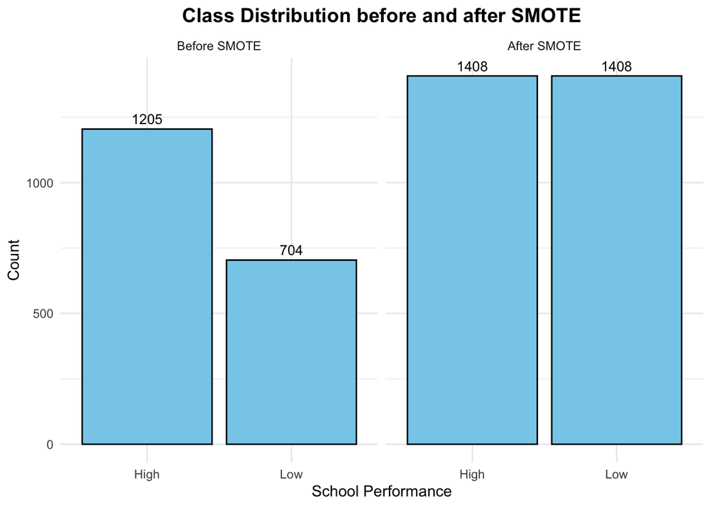

```r
# Class distribution plot
class_distribution_plot <-
  ggplot(compare_distribution, aes(x = performance, y = count)) +
  geom_bar(stat = "identity",
           fill = "skyblue",
           color = "black") +
  geom_text(
    aes(label = count),
    position = position_dodge(width = 0.9),
    vjust = -0.5,
    size = 3.5
  ) +
  facet_wrap( ~ stage) +
  labs(x = "School Performance",
       y = "Count",
       fill = "SMOTE Status",
       title = "Class Distribution before and after SMOTE") +
  theme_minimal() +
  theme(plot.title = element_text(hjust = 0.5, size = 14, face = "bold"))

# Previewing the plot
class_distribution_plot
```

```r
# Saving the plot
ggsave("class_distribution.png", plot = class_distribution_plot, dpi = 600)
```

# 4. Training Classification Models

## 4.1 Classification Tree

Building a baseline model with 10-fold cross-validation to find the best `cp` value.

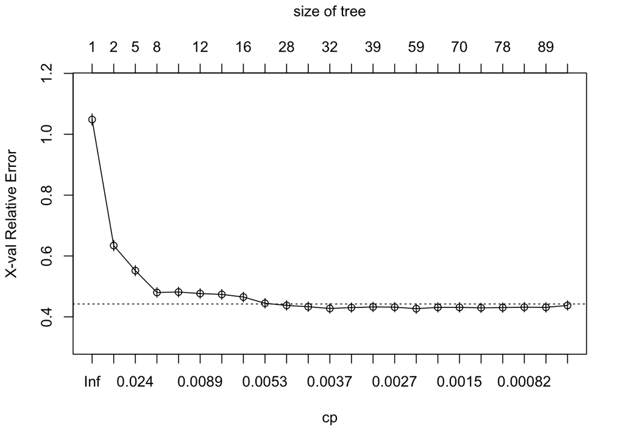

```r
set.seed(7749)

# Baseline model
dt_fit1 <- rpart(formula = performance ~ .,
                 data = data_2022_smote,
                 method = "class",
                 control = rpart.control(minsplit = 20,
                                         cp = 0,
                                         xval = 10),
                 parms = list(split = "gini"))

# The cp plot shows that the 10th dot is the first one that falls under the one-SE line
plotcp(dt_fit1)
```

```r
# The cp value for the 10th model is 0.00426136
printcp(dt_fit1)
```

```
##
## Classification tree:
## rpart(formula = performance ~ ., data = data_2022_smote, method = "class",
##     parms = list(split = "gini"), control = rpart.control(minsplit = 20,
##         cp = 0, xval = 10))
##
## Variables actually used in tree construction:
##  [1] acts_per_1k       books_per_student class_size        days_per_iss
##  [5] days_per_sts      flag_device_home  iss_per_1k        pct_beg_teachers
##  [9] pct_chro_absent   pct_eff_teachers  pct_prov_teachers placement_per_1k
## [13] sts_per_1k        total_funds       total_ppe
##
## Root node error: 1408/2816 = 0.5
##
## n= 2816
##
##            CP nsplit rel error  xerror     xstd
## 1  0.38778409      0   1.00000 1.04830 0.018822
## 2  0.02592330      1   0.61222 0.63423 0.017539
## 3  0.02249053      4   0.53125 0.55185 0.016846
## 4  0.01041667      7   0.46378 0.48011 0.016098
## 5  0.00923295     10   0.43253 0.48153 0.016114
## 6  0.00852273     11   0.42330 0.47656 0.016057
## 7  0.00639205     12   0.41477 0.47372 0.016024
## 8  0.00568182     15   0.39560 0.46520 0.015923
## 9  0.00497159     18   0.37855 0.44460 0.015671
## 10 0.00426136     27   0.33381 0.43750 0.015581
## 11 0.00390625     29   0.32528 0.43324 0.015526
## 12 0.00355114     31   0.31747 0.42756 0.015451
## 13 0.00301847     34   0.30682 0.43040 0.015489
## 14 0.00284091     38   0.29474 0.43253 0.015516
## 15 0.00248580     50   0.25994 0.43182 0.015507
## 16 0.00213068     58   0.23793 0.42685 0.015442
## 17 0.00159801     65   0.22301 0.43111 0.015498
## 18 0.00142045     69   0.21662 0.43111 0.015498
## 19 0.00118371     71   0.21378 0.42969 0.015479
## 20 0.00094697     77   0.20668 0.43040 0.015489
## 21 0.00071023     80   0.20384 0.43182 0.015507
## 22 0.00035511     88   0.19815 0.43111 0.015498
## 23 0.00000000     96   0.19531 0.43750 0.015581
```

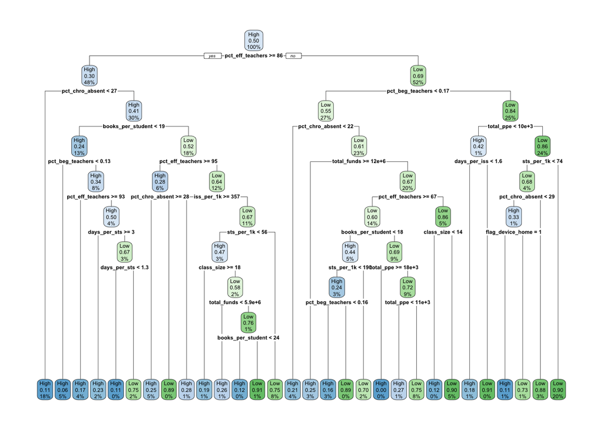

```r
# Using the best cp value we have identified: 0.00426136
dt_fit2 <- rpart(formula = performance ~.,
                 data = data_2022_smote,
                 method = "class",
                 control = rpart.control(minsplit = 20,
                                         cp = 0.00426136,
                                         xval = 0),
                 parms = list(split = "gini"))

# Let's see what the tree looks like
rpart.plot(dt_fit2, tweak = 1.2, compress = FALSE)
```

```r
# Saving the plot
png("dt_big.png", height = 800, width = 1200)
rpart.plot(dt_fit2, tweak = 1.1)
dev.off()
```

We can see that with the best `cp`, the tree is complex, and we can adjust the `maxdepth` parameter to prune it a bit to show the top level layers.

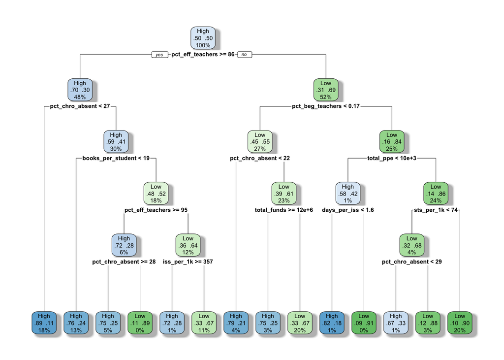

```r
# maxdepth = 5
dt_fit3 <- rpart(formula = performance ~.,
                 data = data_2022_smote,
                 method = "class",
                 control = rpart.control(minsplit = 20,
                                         cp = 0.00426136,
                                         maxdepth = 5,
                                         xval = 0),
                 parms = list(split = "gini"))

# Plot with customized color and format
rpart.plot(dt_fit3, extra = 104, shadow.col = "gray")
```

```r
# Saving the plot
png("dt_prunned.png")
rpart.plot(dt_fit3, extra = 104, shadow.col = "gray")
dev.off()
```

In the classification tree, `total_ppe` (total expenditure per pupil) played an interesting role. Let’s make a visualization to see how different schools are expending their money and where they are spending their funding.

```r
# Getting more detailed ppe broken down by categories
 ppe_data <- src_data_list[["rcd_funds2.xlsx"]] |>
  # 2022 data
  filter(year == 2022) |>
  # Keeping needed variables
  select(agency_code, expenditure_category, total_ppe) |>
  # Reshaping data frame
  pivot_wider(names_from = expenditure_category,
              values_from = total_ppe) |>
  # Lowercase name for clarity
  clean_names()

# Merge with performance classification
ppe_data_vis <- left_join(lp_2022, ppe_data, by = "agency_code") |>
  drop_na()
```

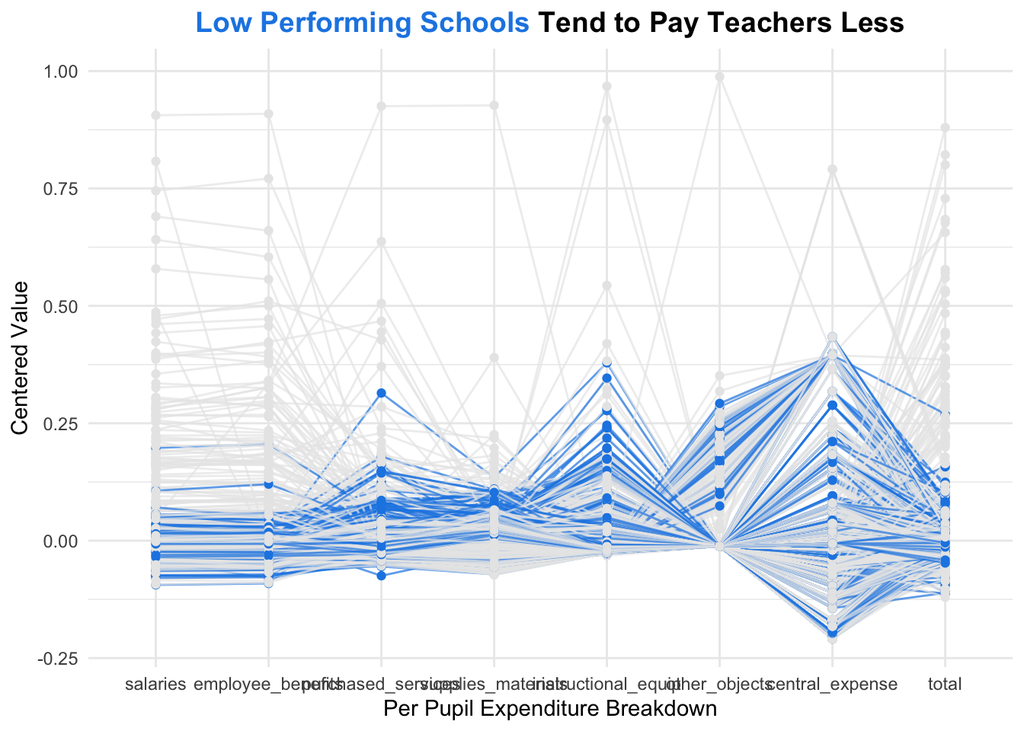

```r
# Plotting
ppe_plot <- ggparcoord(
  ppe_data_vis,
  scale = "center",
  columns = 3:10,
  groupColumn = 2,
  showPoints = TRUE,
  alphaLines = 0.7,
  title = "<span style='color:#1E88E5'>Low Performing Schools</span> Tend to Pay Teachers Less"
) +
  scale_color_manual(values = c("#E8E8E8", "#1E88E5")) +
  theme_minimal() +
  theme(legend.position = "none",
        plot.title = element_markdown(hjust = 0.5, size = 14, face = "bold"))  +
  labs(x = "Per Pupil Expenditure Breakdown",
       y = "Centered Value")

# Displaying plot
ppe_plot
```

```r
# Saving plot
ggsave("ppe_plot.png", ppe_plot, width = 10, height = 6, dpi = 600)
```

In addition to teachers’ pay, their total expenditure is also less though around avergae. Does that have something to do less funding they receive? Let’s see.

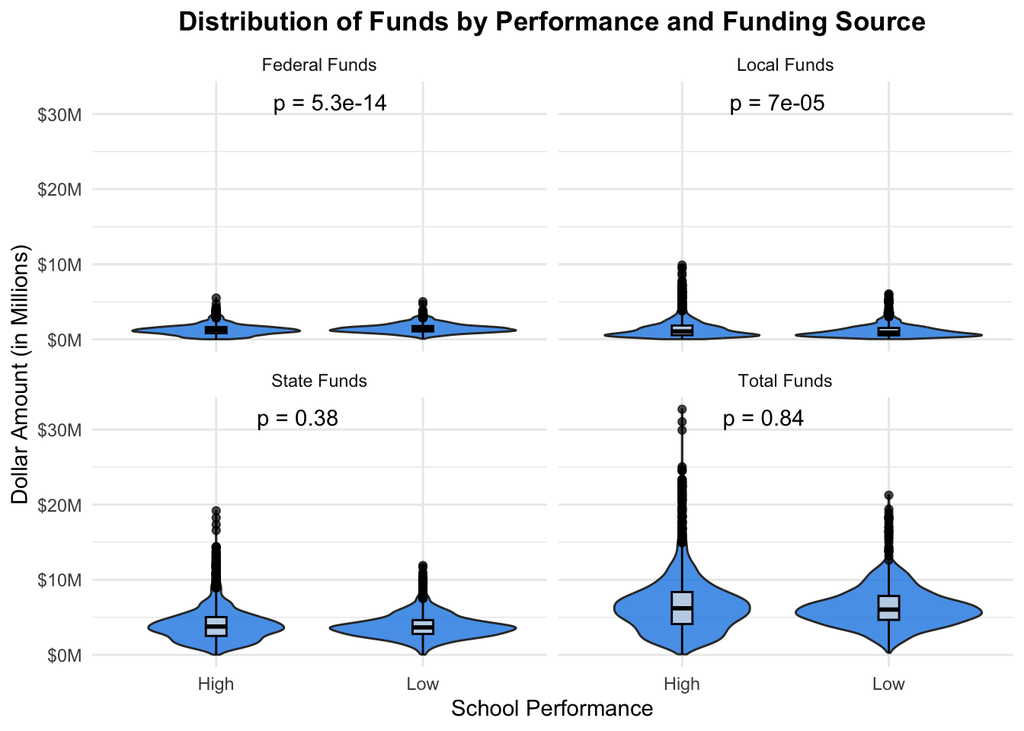

```r
# Getting funds data with source breakdown
funds_breakdown <- src_data_list[["rcd_funds2.xlsx"]] |>
  filter(year == 2022,
         expenditure_category == "TOTAL") |>
  select(agency_code, state_funds, federal_funds, local_funds, total_funds)

# Join with school performance
funds_vis_data <- left_join(lp_2022, funds_breakdown, by = "agency_code") |>
  drop_na() |>
  pivot_longer(cols = c(state_funds, federal_funds, local_funds, total_funds),
               names_to = "fund_source",
               values_to = "amount") |>
  mutate(fund_source = case_when(
    fund_source == "state_funds" ~ "State Funds",
    fund_source == "federal_funds" ~ "Federal Funds",
    fund_source == "local_funds" ~ "Local Funds",
    fund_source == "total_funds" ~ "Total Funds",
    TRUE ~ fund_source  # Ensures no other values are missed
  ))

# Plotting violin plot
funds_distribution_plot <- ggplot(funds_vis_data, aes(x = performance, y = amount)) +
  geom_violin(fill = "#1E88E5", alpha = 0.8) +
  geom_boxplot(
    width = 0.1,
    color = "black",
    fill = "#E8E8E8",
    alpha = 0.7
  ) +
  stat_compare_means(
    method = "wilcox.test",
    label = "p.format",
    vjust = 1,
    hjust = -0.5
  ) +
  facet_wrap( ~ fund_source) +
  scale_y_continuous(labels = label_dollar(scale = 1e-6, suffix = "M")) +
  labs(x = "School Performance", y = "Dollar Amount (in Millions)", title = "Distribution of Funds by Performance and Funding Source") +
  theme_minimal() +
  theme(plot.title = element_text(hjust = 0.5, face = "bold"))

# Displaying plot
funds_distribution_plot
```

```r
# Saving the plot
ggsave(
  filename = "funds_distribution.png",
  plot = funds_distribution_plot,
  width = 8,
  height = 6,
  dpi = 600
)
```

I actually realized a problem after creating this visualization. School size matters! If a large school has the same funding as a small school, the comparison would not make sense without enrollment data. However, no datasets were found from NC DPI.

Also, the tree seems to suggests that the more books per student has, the more likely the schools will be low-performing, which is very counterintuitive. Let’s see what happened.

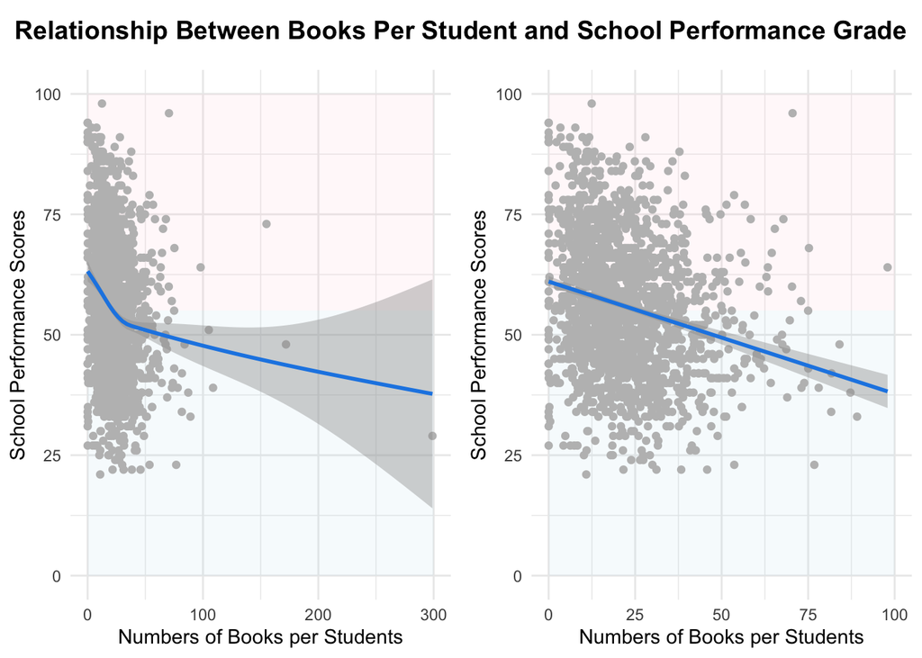

```r
spg_details <- src_data_list[["rcd_acc_spg2.xlsx"]] |>
  filter(year == "2022",
         subgroup == "ALL") |>
  select(agency_code, spg_score, spg_grade)

# We need to merge the school performance data back to data_2022
data_2022_vis <- data_2022 |>
  rownames_to_column(var = "agency_code") |>
  drop_na()

books_vis <- left_join(data_2022_vis, spg_details, by = "agency_code") |>
  select(agency_code, spg_score, spg_grade, books_per_student) |>
  drop_na()

books_plot_full <- ggplot(books_vis, aes(x = books_per_student, y = spg_score)) +
  annotate("rect", xmin = 0, xmax = 300, ymin = 55, ymax = 100, fill = "pink", alpha = 0.1) +
  annotate("rect", xmin = 0, xmax = 300, ymin = 0, ymax = 55, fill = "lightblue", alpha = 0.1) +
  geom_point(color = "grey") +
  geom_smooth(color = "#1E88E5") +

  theme_minimal() +
  scale_y_continuous(limits = c(0, 100)) +

  labs(x = "Numbers of Books per Students",
       y = "School Performance Scores")

zoomed_book_plot <- ggplot(books_vis, aes(x = books_per_student, y = spg_score)) +
  annotate("rect", xmin = 0, xmax = 100, ymin = 55, ymax = 100, fill = "pink", alpha = 0.1) +
  annotate("rect", xmin = 0, xmax = 100, ymin = 0, ymax = 55, fill = "lightblue", alpha = 0.1) +
  geom_point(color = "grey") +
  geom_smooth(color = "#1E88E5", method = "lm") +
  theme_minimal() +
  scale_y_continuous(limits = c(0, 100)) +
  scale_x_continuous(limits = c(0, 100)) +
  labs(x = "Numbers of Books per Students",
       y = "School Performance Scores")


combined_plot_books <- plot_grid(
  books_plot_full, zoomed_book_plot,
  ncol = 2
)
# Adding title
title <- ggdraw() +
  draw_label(
    "Relationship Between Books Per Student and School Performance Grade",
    fontface = "bold",
    size = 14,
    hjust = 0.5
  )

# Combining everything together
combined_plot_books <- plot_grid(
  title,
  plot_grid(books_plot_full, zoomed_book_plot, ncol = 2),
  ncol = 1,
  rel_heights = c(0.1, 1)
)
# Display combined plot
combined_plot_books
```

```r
ggsave("books_plot.png", combined_plot_books, width = 10, height = 6, dpi = 600)
```

## 4.2 Logistic Regression

```r
set.seed(7749)
# 10-fold cross-validation
logistic_cv  <- trainControl(method = "cv", number = 10,
                             # Saving predictions for each fold
                             savePredictions = "all",
                             # Returning class probabilities
                             classProbs = TRUE)

# Fitting the model
logit_fit <- train(performance ~ .,
                   data = data_2022_smote,
                   method = "glm",
                   family = "binomial",
                   trControl = logistic_cv)
```

## 4.3 Random Forest

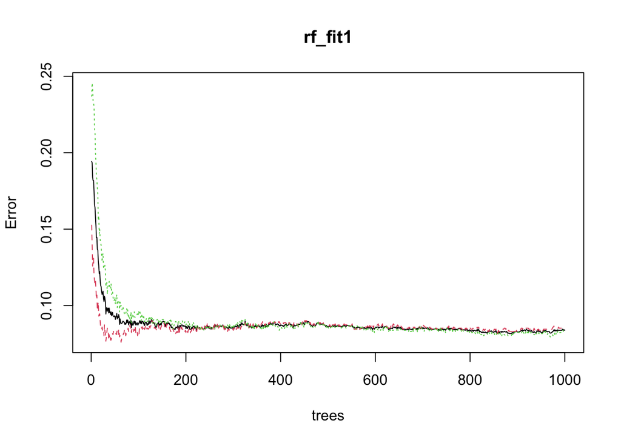

```r
set.seed(7749)
# Starting random forest with 1000 trees
rf_fit1 <- randomForest(formula = performance ~ .,
                        data = data_2022_smote,
                        importance = TRUE,
                        ntree = 1000)

# Plotting the errors
plot(rf_fit1)
```

After 200 trees, all errors begin to be flat, so let’s do `ntree = 200`.

```r
# ntree = 200
set.seed(241216)
rf_fit2 <- randomForest(formula = performance ~ .,
                        data = data_2022_smote,
                        importance = TRUE,
                        ntree = 200)

rf_fit2
```

```
##
## Call:
##  randomForest(formula = performance ~ ., data = data_2022_smote,      importance = TRUE, ntree = 200)
##                Type of random forest: classification
##                      Number of trees: 200
## No. of variables tried at each split: 4
##
##         OOB estimate of  error rate: 8.95%
## Confusion matrix:
##      High  Low class.error
## High 1282  126  0.08948864
## Low   126 1282  0.08948864
```

# 4. Model Evaluation

## 4.1 Making Predictions

- Classification Tree

```r
# Making predictions using dt_fit2 for 2023 data
dt_pred <- predict(dt_fit2, data_2023_cleaned) |>
  as.data.frame() |>
  mutate(prediction = as.factor(ifelse(Low > 0.5, "Low", "High")))
```

- Logistic Regression

```r
# Making predictions using logit_fit1 for 2023 data
logit_pred <- predict(logit_fit, data_2023_cleaned) |>
  as.data.frame() |>
  rename(prediction = "predict(logit_fit, data_2023_cleaned)")
```

- Random Forest

```r
# Making predictions using rf_fit2 for 2023 data
rf_pred <- predict(rf_fit2, data_2023_cleaned) |>
  as.data.frame() |>
  rename(prediction = `predict(rf_fit2, data_2023_cleaned)`)
```

## 4.2 Confusion Matrix

- Classification Tree

```r
# Confusion matrix for dt_fit2
cm_dt <- confusionMatrix(dt_pred$prediction,
                         data_2023_cleaned$performance,
                         positive = "Low")

# Metrics table
dt_cm_table <- data.frame(Value = cm_dt$byClass,
                          Model = "Classification Tree") |>
  rownames_to_column(var = "Metric")
```

- Logistic Regression

```r
# Confusion matrix for logit_fit
cm_logit <- confusionMatrix(logit_pred$prediction,
                            data_2023_cleaned$performance,
                            positive = "Low")

# Metrics table
logit_cm_table <- data.frame(Value = cm_logit$byClass,
                             Model = "Logistic Regression") |>
  rownames_to_column(var = "Metric")
```

- Random Forest

```r
# Confusion matrix for rf_fit2
cm_rf <- confusionMatrix(rf_pred$prediction,
                         data_2023_cleaned$performance,
                         positive = "Low")

# Metrics table
rf_cm_table <- data.frame(Value = cm_rf$byClass,
                          Model = "Random Forest") |>
  rownames_to_column(var = "Metric")
```

## 4.3 ROC AUC

### 4.3.1 Calculating AUC

```r
# Decision Tree
roc_dt <- roc(response = data_2023_cleaned$performance,
                 predictor = factor(dt_pred$prediction, ordered = TRUE))
# Logistic Regression
roc_logit <- roc(response = data_2023_cleaned$performance,
                 predictor = factor(logit_pred$prediction, ordered = TRUE))
# Random Forest
roc_rf <- roc(response = data_2023_cleaned$performance,
    predictor = factor(rf_pred$prediction, ordered = TRUE))
# Creating a metric table
evaluation_metrics_all_models <- bind_rows(dt_cm_table, logit_cm_table, rf_cm_table) |>
  # Reshaping to wide format
  pivot_wider(names_from = Metric, values_from = Value) |>
  # Calculating false alarms rate
  mutate(`1-Specificity` = 1 - Specificity) |>
  # Keeping metrics we want
  select(Model, Sensitivity, Precision, `1-Specificity`) |>
  # Rounding the values
  mutate(Sensitivity = round(Sensitivity, 4),
         Precision = round(Precision, 4),
         `1-Specificity` = round(`1-Specificity`, 4))

# Creating a AUC table
auc_table <- data.frame(Model = c("Classification Tree",
                                  "Logistic Regression",
                                  "Random Forest"),
                        AUC = c(auc(roc_dt),
                                auc(roc_logit),
                                auc(roc_rf))) |>
  # Rounding the values
  mutate(AUC = round(AUC, 4))

# Merging the two tables
evaluation_table <- merge(evaluation_metrics_all_models, auc_table, by = "Model") |>
  # Ordering from largest to smallest
  arrange(desc(AUC))

kable(evaluation_table, format = "markdown", caption = "Evaluation Metrics for Three Models")
```

Evaluation Metrics for Three Models

| Model | Sensitivity | Precision | 1-Specificity | AUC |
| --- | --- | --- | --- | --- |
| Random Forest | 0.7626 | 0.6381 | 0.2032 | 0.7797 |
| Classification Tree | 0.7093 | 0.6070 | 0.2157 | 0.7468 |
| Logistic Regression | 0.6334 | 0.6480 | 0.1616 | 0.7359 |

### 4.3.2 Comparing AUC Values (Delong Test)

```r
# Creating a list
roc_list <- list(roc_dt, roc_logit, roc_rf)
# Creating pairs for comparison
pairs <- combn(seq_along(roc_list), 2, simplify = FALSE)
# Running delong test
delong_test <- lapply(pairs, function(pair) {
  roc.test(roc_list[[pair[1]]], roc_list[[pair[2]]], method = "delong")
})
```

```r
# Confirming the order of tests
pairs
```

```
## [[1]]
## [1] 1 2
##
## [[2]]
## [1] 1 3
##
## [[3]]
## [1] 2 3
```

```r
# Creating a significance stats table for easier comparison
model1 <- c("Classification Tree", "Classification Tree", "Logistic Regression")
model2 <- c("Logistic Regression", "Random Forest", "Random Forest")

z_values <- sapply(delong_test, function(delong_test) round(delong_test$statistic, 3))
p_values <- sapply(delong_test, function(delong_test) ifelse(delong_test$p.value < 0.001, "<0.001", round(delong_test$p.value, 3)))

delong_table <- data.frame(Model1 = model1,
                           Model2 = model2,
                           Z = z_values,
                           p_value = p_values)

kable(delong_table,
      format = "markdown",
      caption = "Significance of AUC Difference for Three Models")
```

Significance of AUC Difference for Three Models

| Model1 | Model2 | Z | p_value |
| --- | --- | --- | --- |
| Classification Tree | Logistic Regression | 1.036 | 0.3 |
| Classification Tree | Random Forest | -4.001 | <0.001 |
| Logistic Regression | Random Forest | -4.558 | <0.001 |

### 4.3.3 Plotting ROC Curves

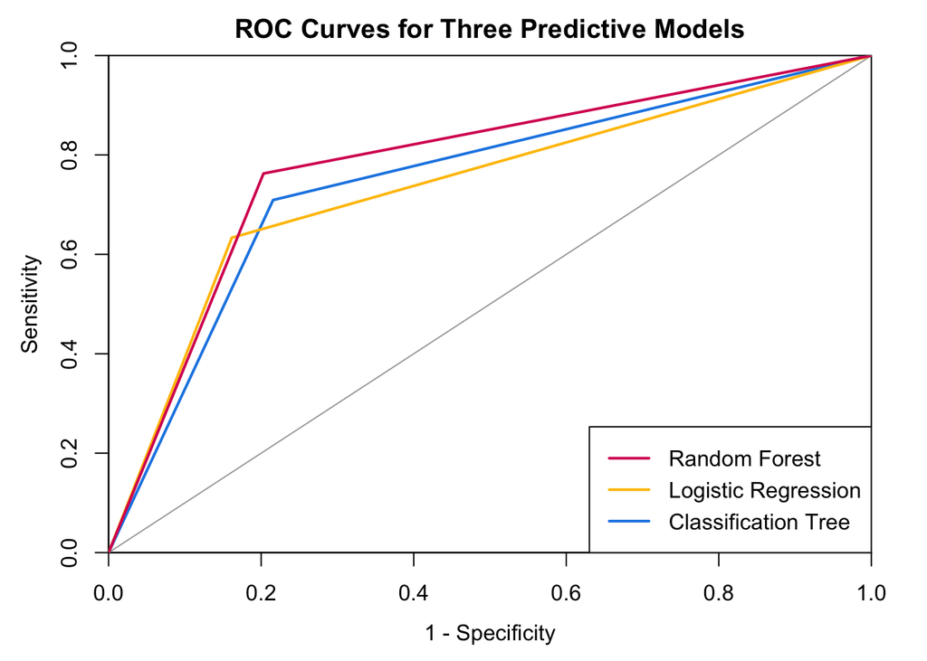

```r
# Plotting ROC curve of classification tree
plot(roc_dt, col = "#1E88E5",
     legacy.axes = TRUE, asp = FALSE, grid = FALSE, lty = 1, lwd = 2,
     xaxs="i", yaxs="i",
     main = "ROC Curves for Three Predictive Models")
# Adding ROC curve of logistic regression
plot(roc_logit, col = "#FFC107", add = TRUE, lty = 1, lwd = 2)
# Adding ROC curve of random forest
plot(roc_rf, col = "#D81B60", add = TRUE, lty = 1, lwd = 2)

legend("bottomright",
       legend = c("Random Forest",
                  "Logistic Regression",
                  "Classification Tree"),
       lty = 1,
       lwd = 2,
       col = c("#D81B60", "#FFC107", "#1E88E5"))
```

## 4.4 Importance of Variables

```r
# Creating a table for variable importance in classification tree
var_impor_dt <- varImp(dt_fit2) |>
  # Converting rownames as column
  rownames_to_column(var = "Variable") |>
  # Rename for clarity
  rename(Importance = Overall)|>
  # Creating a column to signify the model
  mutate(Model = "Classification Tree")

# Getting the variable importance in logistic regression
var_impor_logit_object<- varImp(logit_fit)
# Calculate variable importance
var_impor_logit <- as.data.frame(var_impor_logit_object$importance) |>
  # Converting rownames as column
  rownames_to_column(var = "Variable") |>
  # Rename for clarity
  rename(Importance = Overall) |>
  # Creating a column to signify the model
  mutate(Model = "Logistic Regression")

var_impor_rf <- as.data.frame(importance(rf_fit2)) |>
  # Converting rownames as column
  rownames_to_column(var = "Variable") |>
  # Keep only the relevant columns
  select(Variable, MeanDecreaseAccuracy, MeanDecreaseGini) |>
  # Pivot to long format
  pivot_longer(
    cols = c(MeanDecreaseAccuracy, MeanDecreaseGini),
    names_to = "Model",
    values_to = "Importance"
  ) |>
  # Rename Model column values based on their original name
  mutate(Model = ifelse(Model == "MeanDecreaseAccuracy",
                        "RF: Accuracy",
                        "RF: Gini"))
```

```r
# Combine the three data frames
var_impor_merged <- bind_rows(var_impor_dt, var_impor_logit, var_impor_rf)

# Normalize importance scores within each model
var_impor_normalized <- var_impor_merged |>
  group_by(Model) |>
  mutate(Normalized_Importance = (Importance - min(Importance)) / (max(Importance) - min(Importance))) |>
  ungroup()

# Extract variable order based on "Classification Tree"
reference_order <- var_impor_normalized |>
  filter(Model == "Classification Tree") |>
  arrange(Importance) |>
  pull(Variable)

# Reorder Variable column globally
var_impor_normalized <- var_impor_normalized |>
  mutate(Variable = factor(Variable, levels = reference_order))
```

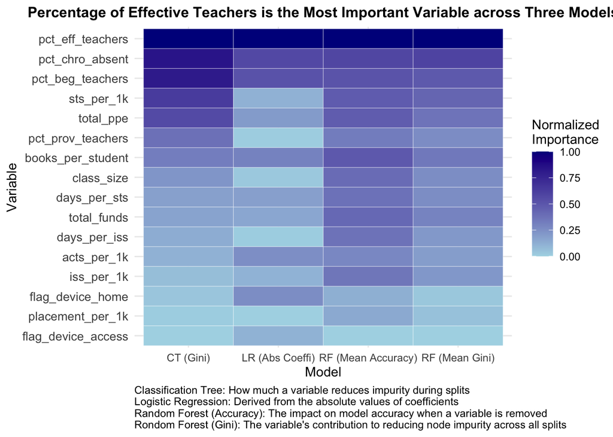

```r
# Create a heatmap
var_impor_heatmap <- ggplot(var_impor_normalized,
                            aes(x = Model, y = Variable, fill = Normalized_Importance)) +
  geom_tile(color = "white") +
  scale_fill_gradient(low = "lightblue",
                      high = "darkblue",
                      name = "Normalized\nImportance") +
  scale_x_discrete(
    labels = c(
      "Classification Tree" = "CT (Gini)",
      "Logistic Regression" = "LR (Abs Coeffi)",
      "RF: Accuracy" = "RF (Mean Accuracy)",
      "RF: Gini" = "RF (Mean Gini)"
    )
  ) +
  labs(
    title = "Percentage of Effective Teachers is the Most Important Variable across Three Models",
    x = "Model",
    y = "Variable",
    caption = "Classification Tree: How much a variable reduces impurity during splits
Logistic Regression: Derived from the absolute values of coefficients
Random Forest (Accuracy): The impact on model accuracy when a variable is removed
Rondom Forest (Gini): The variable's contribution to reducing node impurity across all splits"
  ) +
  theme_minimal() +
  theme(
    axis.text.y = element_text(size = 10),
    plot.title = element_text(hjust = 0.5, size = 12, face = "bold"),
    plot.caption = element_text(hjust = 0)
  )

# Displaying the heatmap
var_impor_heatmap
```

```r
# Saving the heatmap
ggsave("var_impor_heatmap.png", plot = var_impor_heatmap, dpi = 600)
```

Across all models, percentage of effective teachers is an important feature. Let’s explore it more with visualizations.

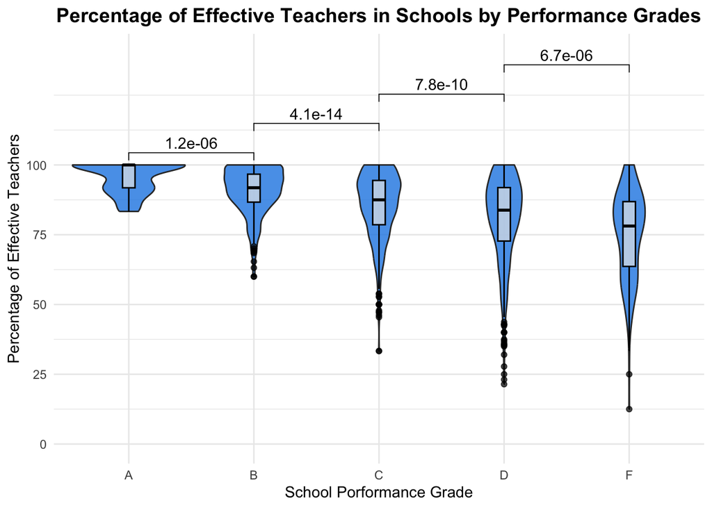

```r
# Getting the detailed school performance with all levels: A, B, C, D, F
spg_details <- src_data_list[["rcd_acc_spg2.xlsx"]] |>
  filter(year == "2022",
         subgroup == "ALL") |>
  select(agency_code, spg_grade, spg_score)

# We need to merge the school performance data back to data_2022
data_2022_vis <- data_2022 |>
  rownames_to_column(var = "agency_code")

# Merge the two datasets
teachers_vis <- left_join(data_2022_vis, spg_details, by = "agency_code") |>
  drop_na() |>
  select(agency_code, spg_grade, spg_score, pct_eff_teachers)

# Creating a boxplot to show the between class difference
eff_teachers_plot <- ggplot(teachers_vis, aes(x = spg_grade, y = pct_eff_teachers)) +
  geom_violin(fill = "#1E88E5", alpha = 0.8) +
  geom_boxplot(
    width = 0.1,
    color = "black",
    fill = "#E8E8E8",
    alpha = 0.7
  ) +
  stat_compare_means(comparisons = list(c("A", "B"), c("B", "C"), c("C", "D"), c("D", "F")), method = "t.test", label = "p.farmat") +
  scale_y_continuous(breaks = c(0, 25, 50, 75, 100), limits = c(0, 140)) +
  labs(x = "School Porformance Grade",
       y = "Percentage of Effective Teachers",
       title = "Percentage of Effective Teachers in Schools by Performance Grades") +
  theme_minimal() +
  theme(plot.title = element_text(hjust = 0.5, size = 14, face = "bold"))

# Displaying plot
eff_teachers_plot
```

```r
# Saving plot
ggsave("eff_teachers_plot.png", eff_teachers_plot, height = 6, width = 8, dpi = 600)
```

# 5. R Packages Used

```r
pkgs <- cite_packages(output = "table",pkgs = "Session", out.dir = ".")
knitr::kable(pkgs)
```

| Package | Version | Citation |
| --- | --- | --- |
| base | 4.3.2 | @base |
| caret | 6.0.94 | @caret |
| cowplot | 1.1.3 | @cowplot |
| DMwR | 0.4.1 | @DMwR |
| GGally | 2.2.1 | @GGally |
| ggpubr | 0.6.0 | @ggpubr |
| ggtext | 0.1.2 | @ggtext |
| janitor | 2.2.0 | @janitor |
| knitr | 1.48 | @knitr2014; @knitr2015; @knitr2024 |
| lattice | 0.22.6 | @lattice |
| pROC | 1.18.5 | @pROC |
| randomForest | 4.7.1.2 | @randomForest |
| rpart | 4.1.23 | @rpart |
| rpart.plot | 3.1.2 | @rpartplot |
| scales | 1.3.0 | @scales |
| tidyverse | 2.0.0 | @tidyverse |
| zip | 2.3.1 | @zip |